# Práctica 2: Limpieza y validación de los datos

Luis Manuel Pérez Geraldino y Sergi Ramirez Mitjans

16/5/2019

# 1. Descripción del dataset

El dataset que a continuación se va a describir, se a obtenido mediante *web scrapping* en la práctica 1 de esta misma asignatura por lo tanto está práctica se tratará de realizar la limpieza del dataset que se consiguió desarrollar en etapas anteriores de esta asignatura.

El conjunto de datos obtenido recoge los medicamentos con más facturación en el mundo farmacéutico. A la vez también esta incorporado los medicamentos más consumidos en España. Este dataset es variable ya que se tendrán tantos medicamentos como el código demande. Esto es posible ya que el código esta preparado para hacer de buscador y extractor de aquellos medicamentos que se pasen por parámetros. Algunas variables de las que encontramos en el dataset sería el precio, nombre del medicamente, genérico o url del Vademecum.

```r
# Leemos los datos para guardar
datos <- read.csv2('result.csv',  sep = ";", header = T, stringsAsFactors = T, dec = ".", encoding = 'latin1')

# Cambiamos el nombre de las columnas para que puedan ser leibles
cols <- c("Medicamento", "URL", "Presentacion", "Codigo_Nacional", "Tipo", "Generico", "Laboratorio", "Estado", "Fecha_Alta", "Fecha_Baja", "Aportacion_Beneficiario", "Principio_Activo", "PVP", "Precio_Referencia", "Menor_Precio_Agrupacion_Homogenea", "Agrupacion_Homogenea", "Diagnostico_Hospitalario", "Tratamiento_Larga_Duracion", "Control_Medico", "Huerfano", "Enfermedad")

colnames(datos) <- cols

# Generamos el archivo metadata
library(Hmisc)
metadata <- contents(datos)
#html(metadata)

# Generamos 3 vectores con la posicion de las columnas según la tipologia de ellas
lista_clase <- sapply(datos, class)
table(lista_clase)
```

```
## lista_clase
##  factor integer logical numeric
##      16       1       1       3
```

```r
# Generamos diferentes variables
var_factor    <- unname(which(lista_clase == 'factor'))
var_numeric   <- unname(which(lista_clase %in% c('numeric', 'integer')))
```

# 2. Integración y selección de datos

## 2.1 Conversión de la tipologia de la variable

```r
# Convertimos las variables a character
# cols <- colnames(datos)[which(!var_factor %in% 7:8)]

cols <- c("Medicamento", "URL", "Presentacion", "Codigo_Nacional", "Tipo", "Generico", "Laboratorio", "Estado", "Aportacion_Beneficiario", "Principio_Activo","Agrupacion_Homogenea", "Fecha_Alta", "Fecha_Baja", "Diagnostico_Hospitalario", "Tratamiento_Larga_Duracion", "Control_Medico", "Huerfano", "Enfermedad")

for(i in cols){
  cat("Transformando variable", i, "...")
  datos[, i] <- as.character(datos[, i])
  cat(" OK\n")
}
```

```
## Transformando variable Medicamento ... OK
## Transformando variable URL ... OK
## Transformando variable Presentacion ... OK
## Transformando variable Codigo_Nacional ... OK
## Transformando variable Tipo ... OK
## Transformando variable Generico ... OK
## Transformando variable Laboratorio ... OK
## Transformando variable Estado ... OK
## Transformando variable Aportacion_Beneficiario ... OK
## Transformando variable Principio_Activo ... OK
## Transformando variable Agrupacion_Homogenea ... OK
## Transformando variable Fecha_Alta ... OK
## Transformando variable Fecha_Baja ... OK
## Transformando variable Diagnostico_Hospitalario ... OK
## Transformando variable Tratamiento_Larga_Duracion ... OK
## Transformando variable Control_Medico ... OK
## Transformando variable Huerfano ... OK
## Transformando variable Enfermedad ... OK
```

## 2.2. Creamos nuevas variables

```r
# Separamos el código de la agrupación
codigos <- strsplit(as.character(datos[, 'Agrupacion_Homogenea']), "-")
data = data.frame(codigo = character(), agrupacion = character(), stringsAsFactors=FALSE)

for (i in 1:length(codigos)){
    if(codigos[i][1] == ""){
      data[i, 1] = NA
      data[i, 2] = NA
    } else {
      data[i, 1] = as.character(codigos[[i]][1])
      data[i, 2] = as.character(codigos[[i]][2])
    }
}

datos[, 'Codigo_Agrupacion'] <- data[, 'codigo']

# Realizamos la separación por laboratorio
lab <- strsplit(as.character(datos[, 'Laboratorio']), ",")
data = data.frame(codigo = character(), laboratorio = character(), sociedad =  character(), stringsAsFactors = FALSE)

for (i in 1:length(codigos)){
    if(length(lab[[i]]) == 3){
      valor1 = as.character(lab[[i]][1])
      valor2 = as.character(lab[[i]][2])
      valor3 = as.character(lab[[i]][3])
    } else {
      if (length(lab[[i]]) == 2){
      valor1 = as.character(lab[[i]][1])
      valor2 = as.character(lab[[i]][2])
      valor3 = ""
      } else {
      valor1 = ""
      valor2 = as.character(lab[[i]][2])
      valor3 = ""
      }
    }
    data[i, 1] = valor1
    data[i, 2] = valor2
    data[i, 3] = valor3
}

datos[, 'Codigo_Laboratorio'] <- data[, 'codigo']

# Creamos la variable Baja que consiste en si el medicamento esta o no esta dado de baja
datos[, 'Baja'] <- ifelse(datos[, 'Fecha_Baja'] == "", "NO", "SI")
```

### Selección de los datos de interés

```r
cols <- c("Codigo_Nacional", "Medicamento", "Presentacion", "Tipo", "Laboratorio", "Estado", "Aportacion_Beneficiario", 'Principio_Activo', "PVP", "Agrupacion_Homogenea", "Tratamiento_Larga_Duracion", "Enfermedad", "Baja",'Codigo_Laboratorio', 'Codigo_Agrupacion')

BBDD_seleccion <- datos[, which(colnames(datos) %in% cols)]
```

# 3. Limpieza de datos

Por lo tanto, nos replanteamos la idea de imputar las variables `Precio_Referencia` y `Menor_Precio_Agrupacion_Homogenea`. Eliminamos la variable `Generico` ya que el 100% corresponde a NA’s.

```r
# Eliminamos la variable Generico de nuestro conjunto de datos
datos[, 'Generico'] <- NULL
```

A continuación hacemos que todos los códigos tengan el mismo número de dígitos.

```r
table(nchar(datos[, 'Codigo_Nacional']))
```

```
##
##    6
## 1503
```

```r
table(nchar(datos[, 'Codigo_Laboratorio']))
```

```
##
##   2   3   4
##  41 819 643
```

```r
datos[, 'Codigo_Laboratorio'] <- sprintf("%0.4d", as.numeric(datos[, 'Codigo_Laboratorio']))
table(nchar(datos[, 'Codigo_Agrupacion']))
```

```
##
##    3    4    5
##   20  165 1243
```

```r
datos[, 'Codigo_Agrupacion'] <- sprintf("%0.5d", as.numeric(datos[, 'Codigo_Agrupacion']))
```

Como tenemos en variables numéricas valores NA’s deberemos de imputar estos registros para obtener los que realmente se consideren más cercanos. Para ello utilizaremos un método de imputación llamado *MICE*.

```r
# https://www.analyticsvidhya.com/blog/2016/03/tutorial-powerful-packages-imputing-missing-values/

# http://rpubs.com/ydmarinb/429757

# https://rpubs.com/medusa/128029

library(VIM)
library(FactoMineR)
library(tidyr)
library(dplyr)
library(magrittr)
library(mice)
```

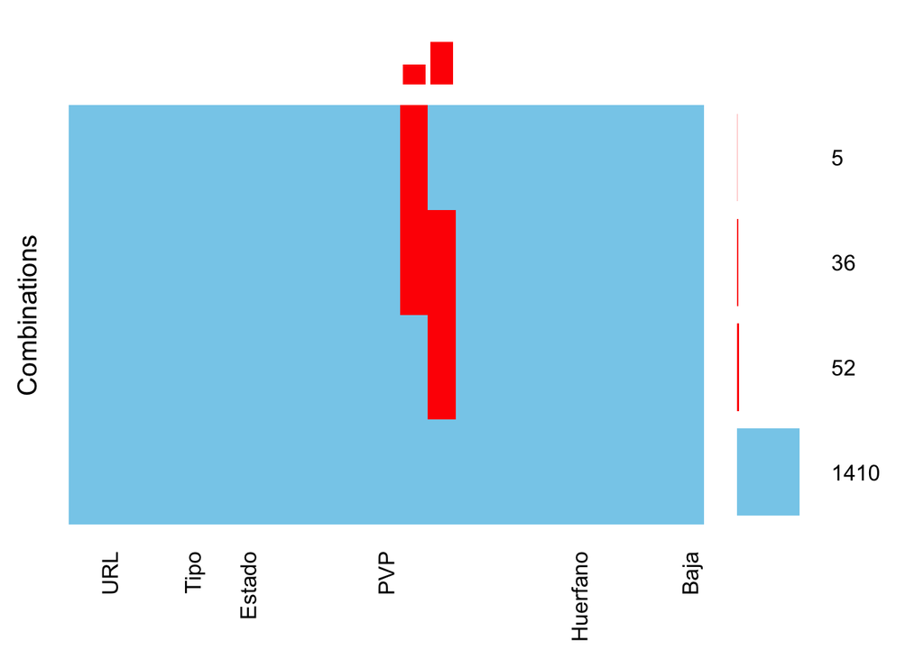

```r
# 1) Primero vamos a ver los patrones
aggr(datos, prop=FALSE,
     numbers=TRUE, border=NA,
     combine=TRUE)
```

```r
variables <- c(var_numeric)
Datos_imputados <- mice(datos[, names(datos) %in% colnames(datos)[variables]]
, m=5, seed = 2018)
Datos_imputados <- mice(datos[, names(datos) %in% colnames(datos)[variables]])
```

[figure not shown]

```r
completeData <- complete(Datos_imputados)

aggr(completeData)
```

Como sabemos que nuestra variable categórica contiene el valor “-” que representa NA’s vamos a tratarlos para que aparezcan como NA’s

```r
# Tratamos el valor "-" de la variable 'Agrupacion_Homogenea' como dato faltante
quienes <- which(BBDD_seleccion['Agrupacion_Homogenea'] == "-")
BBDD_seleccion[quienes, 'Agrupacion_Homogenea'] <- NA
```

A continuación y para realizar una correcta limpieza de los datos comprobamos como esta nuesto dataframe.

```r
# Generamos el archivo metadata
metadata2 <- Hmisc::contents(BBDD_seleccion)
html(metadata2)
```

#### Data frame:BBDD_seleccion

1503 observations and 15 variables, maximum # NAs:75

| Name | Storage | NAs |
| --- | --- | --- |
| Medicamento | character | 0 |
| Presentacion | character | 0 |
| Codigo_Nacional | character | 0 |
| Tipo | character | 0 |
| Laboratorio | character | 0 |
| Estado | character | 0 |
| Aportacion_Beneficiario | character | 0 |
| Principio_Activo | character | 0 |
| PVP | double | 0 |
| Agrupacion_Homogenea | character | 75 |
| Tratamiento_Larga_Duracion | character | 0 |
| Enfermedad | character | 0 |
| Codigo_Agrupacion | character | 75 |
| Codigo_Laboratorio | character | 0 |
| Baja | character | 0 |

## 3.1. Ceros y elementos vacíos

Primero de todo vamos a mirar donde tenemos NA’s y cuantos NA’s hay por cada variable.

```r
NAs <- data.frame(absoluto = colSums(is.na(BBDD_seleccion)))
NAs[, 'porcentaje'] <- round((NAs$absoluto/nrow(BBDD_seleccion))*100, 2)
NAs
```

|  | absoluto | porcentaje |
| --- | --- | --- |
| Medicamento | 0 | 0.00 |
| Presentacion | 0 | 0.00 |
| Codigo_Nacional | 0 | 0.00 |
| Tipo | 0 | 0.00 |
| Laboratorio | 0 | 0.00 |
| Estado | 0 | 0.00 |
| Aportacion_Beneficiario | 0 | 0.00 |
| Principio_Activo | 0 | 0.00 |
| PVP | 0 | 0.00 |
| Agrupacion_Homogenea | 75 | 4.99 |

[output cut: 5 more lines]

Vemos como obtenemos un 5% de valores perdidos en la variable `Agrupacion_Homogenea` y la variable que deriva de ella `Codigo_Agrupacion`. Por lo tanto deberemos de tratarla para que desaparezcan este porcentaje de NA’s.

Para ello crearemos una nueva categoria de la variable que sea `99999 - SIN AGRUPACION`.

```r
qui2 <- which(is.na(BBDD_seleccion[, 'Codigo_Agrupacion']))
BBDD_seleccion[qui2, 'Codigo_Agrupacion'] <- '99999'
qui2 <- which(is.na(BBDD_seleccion[, 'Agrupacion_Homogenea']))
BBDD_seleccion[qui2, 'Agrupacion_Homogenea'] <- '99999 - SIN AGRUPACION'
```

Volvemos a comprobar que hayamos eliminado los valores perdidos que obtenemos de nuestra base de datos.

```r
NAs <- data.frame(absoluto = colSums(is.na(BBDD_seleccion)))
NAs[, 'porcentaje'] <- round((NAs$absoluto/nrow(BBDD_seleccion))*100, 2)
NAs
```

|  | absoluto | porcentaje |
| --- | --- | --- |
| Medicamento | 0 | 0 |
| Presentacion | 0 | 0 |
| Codigo_Nacional | 0 | 0 |
| Tipo | 0 | 0 |
| Laboratorio | 0 | 0 |
| Estado | 0 | 0 |
| Aportacion_Beneficiario | 0 | 0 |
| Principio_Activo | 0 | 0 |
| PVP | 0 | 0 |
| Agrupacion_Homogenea | 0 | 0 |

[output cut: 5 more lines]

## 3.2. Valores extremos

A continuación vamos a calcular si tenemos valores extremos para ello vemos la variable numérica mediante un boxplot.

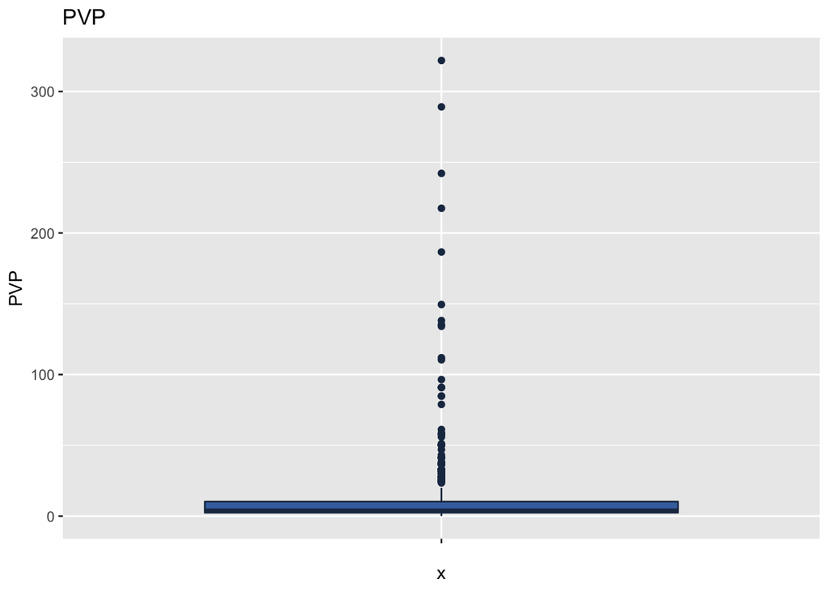

```r
fill <-  "#4271AE"
line <-  "#1F3552"

par(mfrow= c (1,2), mar = c(5,4,2,1))
p10 <- ggplot(data = BBDD_seleccion, aes(x = "", y = PVP))  +
       geom_boxplot (fill = fill , color = line) +
        ggtitle ( "PVP" )
p10
```

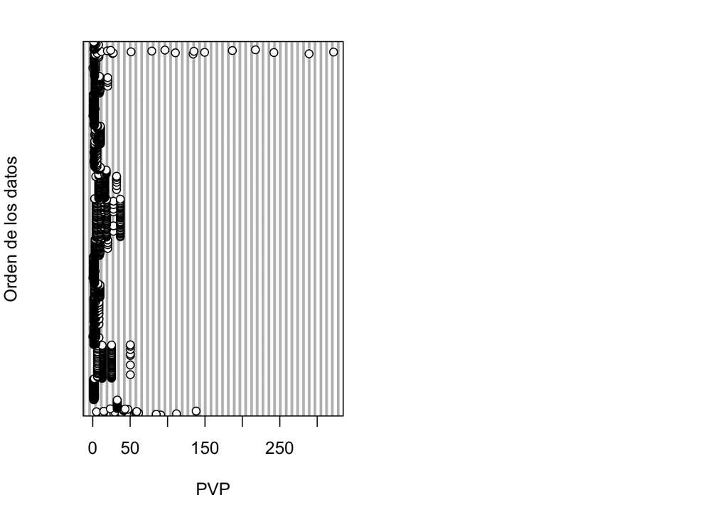

```r
dotchart(BBDD_seleccion$PVP, xlab = "PVP",  ylab = "Orden de los datos")
par(mfrow= c (1,1))
```

Como podemos comprobar tenemos Outliers. Deberemos de trabajar con ellos.

```r
boxplot.stats(datos$PVP)$out
```

```
##   [1]  30.29  90.86  90.86  90.86  30.29  84.80  84.80  55.95 111.90  27.97
##  [11]  61.19  57.70  38.47  57.70  29.41  58.82 138.16  41.28  41.28  41.28
##  [21]  41.28  41.28  41.28  46.97  43.21  23.46  32.72  32.72  32.72  32.72
##  [31]  32.72  32.72  32.72  32.72  32.72  32.72  32.72  32.72  32.72  32.72
##  [41]  32.72  32.72  32.72  32.72  32.72  32.72  32.72  32.72  32.72  32.72
##  [51]  32.72  32.72  32.72  32.72  32.72  32.72  32.72  32.72  32.72  32.72
##  [61]  32.72  25.10  25.10  25.10  25.10  25.10  25.10  50.20  25.10  25.10
##  [71]  25.10  25.10  25.10  25.10  25.10  25.10  25.10  25.10  25.10  50.20
##  [81]  25.10  25.10  25.10  25.10  25.10  25.10  25.10  25.10  25.10  25.10
##  [91]  25.10  25.10  25.10  50.20  25.10  25.10  50.20  25.10  25.10  25.10
## [101]  25.10  25.10  25.10  50.20  25.10  25.10  25.10  50.20  25.10  25.10
## [111]  50.20  36.84  36.84  36.84  36.84  36.84  27.63  36.84  36.84  36.84
## [121]  36.84  36.84  27.63  36.84  36.84  36.84  36.84  36.84  36.84  36.84
## [131]  36.84  36.84  36.84  36.84  36.84  36.84  27.63  36.84  36.84  27.63
## [141]  36.84  36.84  36.84  36.84  27.63  36.84  36.84  36.84  27.63  36.84
## [151]  36.84  31.85  31.85  31.85  31.85  31.85  31.85 134.10 289.13  26.40
## [161]  27.32 110.43 242.12 149.49 321.89  51.16 135.24  78.90 186.59  23.88
## [171]  96.46 217.47
```

```r
shapiro.test(datos$PVP)
```

```
##
##  Shapiro-Wilk normality test
##
## data:  datos$PVP
## W = 0.39369, p-value < 2.2e-16
```

```r
shapiro.test(log(datos[,'PVP']))
```

```
##
##  Shapiro-Wilk normality test
##
## data:  log(datos[, "PVP"])
## W = 0.96795, p-value < 2.2e-16
```

```r
shapiro.test(sqrt(datos[,'PVP']))
```

```
##
##  Shapiro-Wilk normality test
##
## data:  sqrt(datos[, "PVP"])
## W = 0.76339, p-value < 2.2e-16
```

Como vemos en nuestros contrastes, podemos decir que tanto los datos originales como los datos en formato de logaritmo tienen poca normalidad. Por ello lo que vamos hacer es sospechas de que existe 2 grupos diferenciados uno que serian aquellos medicamentos que tienen un coste muy elevado ya que són tratamientos específicos para enfermedades importantes y otro conjunto de datos que tienen un precio más asequible para la población.

Contrastemos esta idea que acabamos de plantear.

Para ello vamos a separar en dos conjuntos. El primer conjunto seran todos los valores que esten por debajo del tercer quartil y el segundo grupo aquellos conjuntos de datos que esten por encima de este valor.

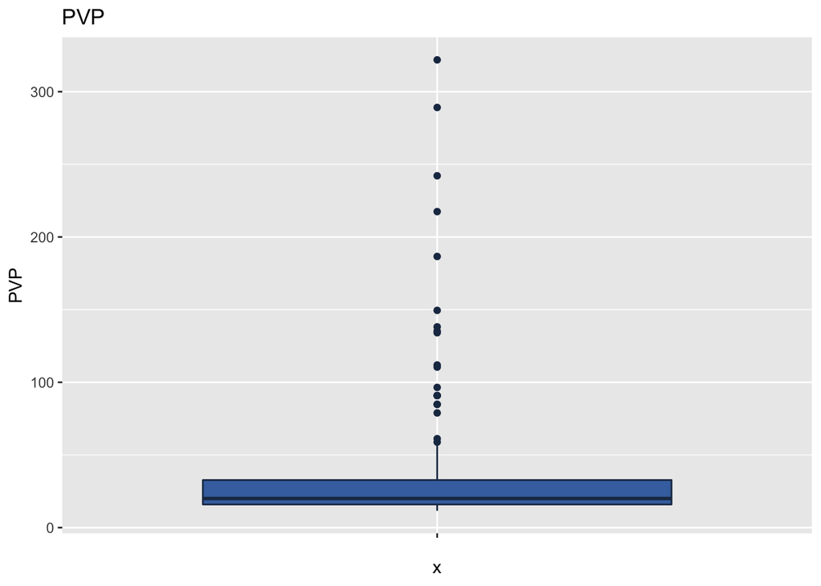

```r
valor_corte <- quantile(datos[, 'PVP'], 0.75)
quienes <- which(datos[, 'PVP'] <= valor_corte)

p10 <- ggplot(data = BBDD_seleccion[-quienes, ], aes(x = "", y = PVP))  +
       geom_boxplot (fill = fill , color = line) +
        ggtitle ( "PVP" )
p10
```

```r
# Comprovamos el test por grupos
shapiro.test(datos[-quienes, 'PVP'])
```

```
##
##  Shapiro-Wilk normality test
##
## data:  datos[-quienes, "PVP"]
## W = 0.45587, p-value < 2.2e-16
```

```r
shapiro.test(log(datos[-quienes,'PVP']))
```

```
##
##  Shapiro-Wilk normality test
##
## data:  log(datos[-quienes, "PVP"])
## W = 0.86692, p-value < 2.2e-16
```

```r
shapiro.test(sqrt(datos[-quienes,'PVP']))
```

```
##
##  Shapiro-Wilk normality test
##
## data:  sqrt(datos[-quienes, "PVP"])
## W = 0.68553, p-value < 2.2e-16
```

# 4. Análisis de los datos

## 4.1. Selección de grupos de datos a analizar

## 4.2 Comprobación de normalidad y homogeneidad de la varianza

```r
library(nortest)
alpha = 0.05
col.names = colnames(datos)
for (i in 1:ncol(datos)) {
  if (i == 1) cat("Variables que no siguen una distribución normal:\n")
  if (is.integer(datos[,i]) | is.numeric(datos[,i])) {
    p_val = ad.test(datos[,i])$p.value
    if (p_val < alpha) {
      cat("  - ")
      cat(col.names[i])
      cat("\n")
    }
  }
}
```

```
## Variables que no siguen una distribución normal:
##   - PVP
##   - Precio_Referencia
##   - Menor_Precio_Agrupacion_Homogenea
```

```r
library(arules)
datos$Categoria_PVP <- discretize(datos$PVP, labels = c('A', 'B', 'C'))
```

```r
fligner.test(PVP ~ Categoria_PVP, data = datos)
```

```
##
##  Fligner-Killeen test of homogeneity of variances
##
## data:  PVP by Categoria_PVP
## Fligner-Killeen:med chi-squared = 791.44, df = 2, p-value <
## 2.2e-16
```

## 4.3. Pruebas estadísticas

### 4.3.2. ¿El precio del medicamento es influido por el laboratorio que lo genera?

### 4.3.3. Modelo de predicción del precio

```r
BBDD_seleccion[, 'log_PVP'] <- log(BBDD_seleccion[, 'PVP'])

# A continuación generamos nuestro modelo lineal. Para ello primero de todo vamos a hacer los pasos de stepwise para que se escojan automaticamente aquellas variables que sean importantes para el modelo.

library(MASS)
cols <- c("log_PVP", 'Presentacion', 'Tipo', 'Estado', 'Aportacion_Beneficiario', 'Tratamiento_Larga_Duracion', 'Enfermedad', 'Codigo_Laboratorio', 'Baja')

dataRegresion <- BBDD_seleccion[, cols]

for(i in colnames(dataRegresion)){
  if(i != 'log_PVP'){
    dataRegresion[, i] <- as.factor(dataRegresion[, i])
  }
}

full.model <- lm(log_PVP ~ ., data = dataRegresion)
step.model <- stepAIC(full.model, direction = "both", trace = FALSE)

# =============================================================================================================
# También realizamos el modelo a través de PLS (Regresión de mínimos cuadrados parciales)
#library(plspm)
#x <- dataRegresion[, which(!colnames(dataRegresion) %in% "PVP")]
#y <- dataRegresion$log_PVP
#modelo <- plspm::plsreg1(x, y, nc = 10, cv = TRUE)
```

### 4.3.4. Recomendador de medicamentos

En este caso cambiamos nuestra variable respuesta y actualmente seria el nombre del producto como variable respuesta.

```r
# Nos quedamos con los datos necesarios
dataTree <- BBDD_seleccion

# Primero de todo transformamos los numericos en categoricos

# Dividimos la muestra en train and test
#Sample Indexes
indexes = sample(1:nrow(data), size=0.2*nrow(data))
```

# 5. Representación de resultados

# 6. Resolución del problema

# 7. Futuras lineas de trabajo

# 8. Código

El código del proyecto se encuentra en el repositorio libre de Github. [Enlace](https://github.com/lmgeraldino/vademecum-consolidation).